# Lab 13

Blue Team: Matt Lawson, Bing Mitchell, Brandon Bowen, Nick Zimmerman

# Team Section

**Has average energy consumption per person changed from the 1980s to the 2000s?**

**Description of the Datasets:**

This data comes from Gapminder about energy consumption in the world.

```r
  total <- read_csv("energy_use_per_person.csv")  %>%
  gather(2:53, key="year", value="TotalperPerson", convert = TRUE)  %>% na.omit()

 # TOE per person = Coal consuumption per person (in Tons of Oil Equivalency)
total80 <- total %>% filter(between(year, 1980, 1989)) %>% select(year, TotalperPerson)
total00 <- total %>% filter(between(year, 2000, 2009)) %>% select(year, TotalperPerson)
```

```r
permTestTeam <- function(x, y, n, func) {
  set.seed(1)
  output <- vector("double", length(n))
  master <- rbind(x, y)
  for (i in c(1:n)) {
    sample <- sample(nrow(master), min(nrow(x), nrow(y)))
    randomX <- master[sample,]
    randomY <- master[-sample,]

    meanX <- map_dbl(randomX, func)
    meanY <- map_dbl(randomY, func)

    output[[i]] <- meanX[[2]] - meanY[[2]]
  }
  return(output)
}
```

```r
statTeam <- permTestTeam(total80, total00, 1000, mean)
TeamrealX <- mean(total80$TotalperPerson)
TeamrealY <- mean(total00$TotalperPerson)
percentile <- sum(statTeam < (TeamrealX-TeamrealY))/length(statTeam)*100
```

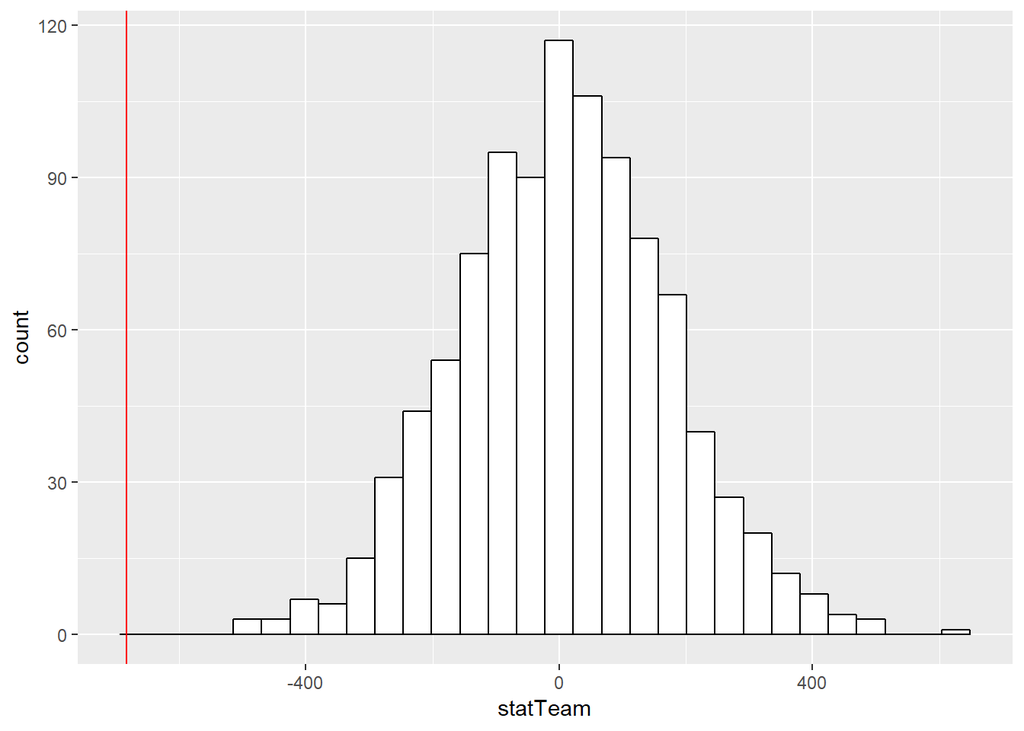

## Bing

Sub Question: Has nuclear energy use increased from 1989 to 2009?

Null Hypothesis: Nuclear Energy use per person hasnt changed in European countries from 1989 to 2009

Alternate Hypothesis: Nuclear Energy use per person has increased in European coutnries from 1989 to 2009

Test Statistic: The average of 2009 - the average of 1989

permTest Function

it is a perumation test that takes in values for 2 years and gives the mean difference in nuclear use per year

```r
permTestBING <- function(x, y, n) {
  output <- vector("double", length(n))
  master <- rbind(x, y)
  nrow(master);nrow(x)
  for (i in c(1:n)) {
    sample <- sample(nrow(master), min(nrow(x), nrow(y)))
    randomX <- master[sample,]
    randomY <- master[-sample,]
    meanX <- mean(randomX$TOEperPerson)
    meanY <- mean(randomY$TOEperPerson)

    # print(meanX); print(meanY)

    output[[i]] <- meanX - meanY
  }
  return(output)
}
```

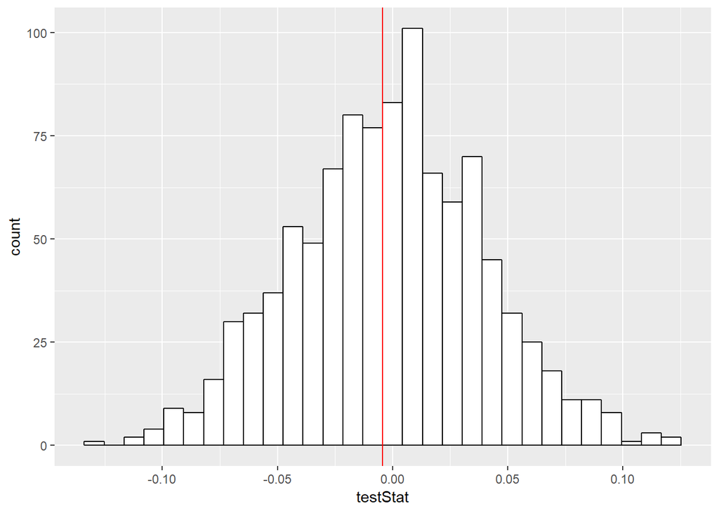

We get that the change in Nuclear use from 1989 to 2009 is only the 46th percentile, so we fail to reject our null hypthesis that there hasn’t been a change in the nuclear use in the time from 1989 to 2009.

## Matt

$\bf{H_0:}$ There is no difference in average coal consumption in the 1980s and the average coal consumption in the 2000s

$\bf{H_1:}$ There is a significant difference in average coal consumption in the 1980s and the average coal consumption in the 2000s

**Test Statistic:** Difference in sample means $\bar{X}_x - \bar{X}_y$

**Subquestion: Is there a difference in coal consumption from the 1980s to the 2000s?**

If there is a difference in energy consumption per person from these decades, then maybe there is a difference in coal consumption during the same time.

**Map Function**

`meanX <- map_dbl(randomX, func); meanY <- map_dbl(randomY, func)`

This `map_dbl` function takes in a dataframe and applies the function `func` to the columns of it.

**Function with Function Argument**

the function `permTestMATT` below takes in an argument called `func`. `func` gets uses in the map above.

```r
  coal <- read_csv("coal_consumption_per_cap.csv")  %>%
  gather(2:53, key="year", value="TOEperPerson", convert = TRUE)  %>% na.omit()

 # TOE per person = Coal consuumption per person (in Tons of Oil Equivalency)
coal80 <- coal %>% filter(between(year, 1980, 1989)) %>% select(year, TOEperPerson)
coal00 <- coal %>% filter(between(year, 2000, 2009)) %>% select(year, TOEperPerson)
```

```r
permTestMATT <- function(x, y, n, func) {
  set.seed(1)
  output <- vector("double", length(n))
  master <- rbind(x, y)
  for (i in c(1:n)) {
    sample <- sample(nrow(master), min(nrow(x), nrow(y)))
    randomX <- master[sample,]
    randomY <- master[-sample,]

    meanX <- map_dbl(randomX, func)
    meanY <- map_dbl(randomY, func)

    output[[i]] <- meanX[[2]] - meanY[[2]]
  }
  return(output)
}
```

```r
statMatt <- permTestMATT(coal80, coal00, 1000, mean)
realX <- mean(coal80$TOEperPerson)
realY <- mean(coal00$TOEperPerson)
percentile <- sum(statMatt < (realX-realY))/length(statMatt)*100
```

The real data is the 96.3 percentile of the random distribution.

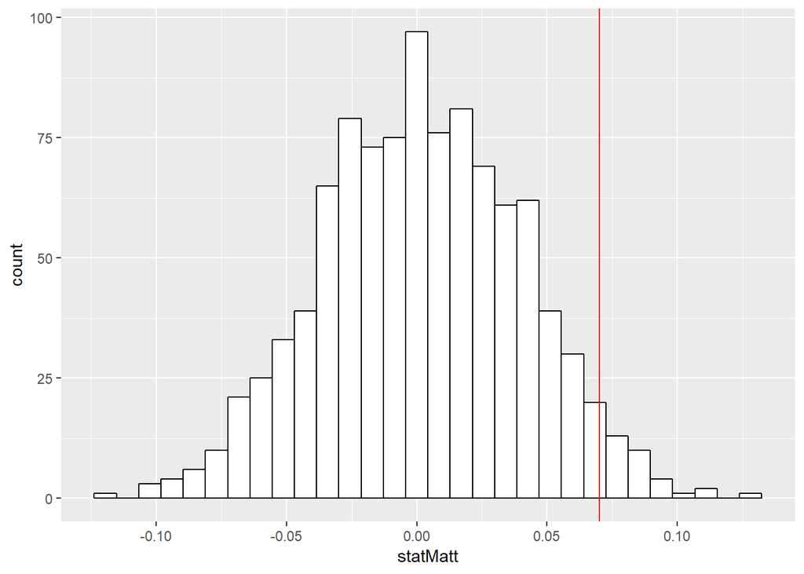

## Brandon

Sub Question: is ther a change of hydro energy consumption per person from 1989 to 2009

Null Hypothesis: There is no signifigant change in energy consumption

Alternative: There is signifigant change in energy consumption

```r
  hydro <- read_csv("hydro_power_generation_per_person.csv")  %>%
  gather(2:53, key="year", value="HydroperPerson", convert = TRUE)  %>% na.omit()

 # Hydro per person = Hydro consumption per person
hydro80 <- hydro %>% filter(between(year, 1980, 1989)) %>% select(year, HydroperPerson)
hydro09 <- hydro %>% filter(between(year, 2000, 2009)) %>% select(year, HydroperPerson)
```

```r
permTestBrandon <- function(x, y, n, func) {
  set.seed(1)
  output <- vector("double", length(n))
  master <- rbind(x, y)
  for (i in c(1:n)) {
    sample <- sample(nrow(master), min(nrow(x), nrow(y)))
    randomX <- master[sample,]
    randomY <- master[-sample,]

    meanX <- map_dbl(randomX, func)
    meanY <- map_dbl(randomY, func)

    output[[i]] <- meanX[[2]] - meanY[[2]]
  }
  return(output)
}
```

```r
stat <- permTestBrandon(hydro80, hydro09, 1000, mean)
realsX <- mean(hydro80$HydroperPerson)
realsY <- mean(hydro09$HydroperPerson)
percentile <- sum(stat < (realsX-realsY))/length(stat)*100
```

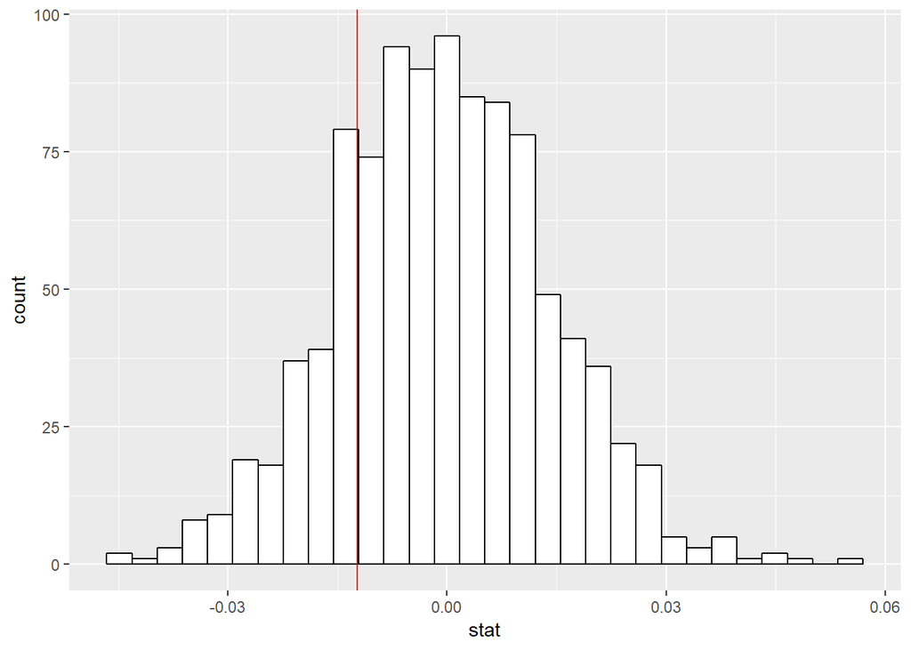

From the graph it can be seen that hydro energy consumption has changed from the 1980’s to the 2000’s but it is not that signifignt

### Nick

Sub question: Has Europe’s consumption of oil experienced a significant decrease from 1985 to 2010

Null hypothesis: Consumption hasn’t changed

Altenate hypothesis: Consumption has changed

Test statistic: Average oil consumption per person in Europe

```r
library(gapminder)
europe_countries <- gapminder %>% filter(continent == "Europe")
europe_countries <- unique(europe_countries$country)

oil <- read_csv("oil_consumption_per_cap.csv")
oil <- filter(oil, country %in% europe_countries)
oil <- oil %>% gather(2:53, key = "year", value = "Oil/Person", na.rm = TRUE, convert = TRUE)

oil_1985 <- oil %>% filter(between(year, 1985, 1990)) %>% select(year, `Oil/Person`)
oil_2010 <- oil %>% filter(between(year, 2005, 2010)) %>% select(year, `Oil/Person`)
```

[figure not shown]

# Lab 13

Blue Team: Matt Lawson, Bing Mitchell, Brandon Bowen, Nick Zimmerman

# Team Section

**Has average energy consumption per person changed from the 1980s to the 2000s?**

**Description of the Datasets:**

## Bing

Sub Question: Has nuclear energy use increased from 1989 to 2009?

Null Hypothesis: Nuclear Energy use per person hasnt changed in European countries from 1989 to 2009

Alternate Hypothesis: Nuclear Energy use per person has increased in European coutnries from 1989 to 2009

Test Statistic: The average of 2009 - the average of 1989

permTest Function

it is a perumation test that takes in values for 2 years and gives the mean difference in nuclear use per year

```r
permTestBING <- function(x, y, n) {
  output <- vector("double", length(n))
  master <- rbind(x, y)
  nrow(master);nrow(x)
  for (i in c(1:n)) {
    sample <- sample(nrow(master), min(nrow(x), nrow(y)))
    randomX <- master[sample,]
    randomY <- master[-sample,]
    meanX <- mean(randomX$TOEperPerson)
    meanY <- mean(randomY$TOEperPerson)

    # print(meanX); print(meanY)

    output[[i]] <- meanX - meanY
  }
  return(output)
}
```

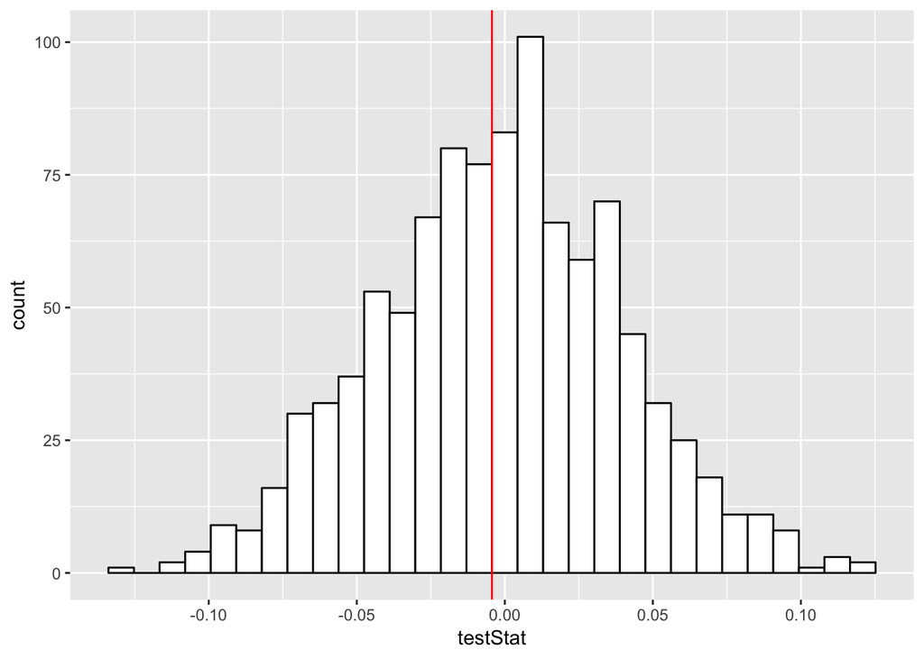

We get that the change in Nuclear use from 1989 to 2009 is only the 46th percentile, so we fail to reject our null hypthesis that there hasn’t been a change in the nuclear use in the time from 1989 to 2009.

## Matt

$\bf{H_0:}$ There is no difference in average coal consumption in the 1980s and the average coal consumption in the 2000s

$\bf{H_1:}$ There is a significant difference in average coal consumption in the 1980s and the average coal consumption in the 2000s

**Test Statistic:** Difference in sample means $\bar{X}_x - \bar{X}_y$

**Subquestion: Is there a difference in coal consumption from the 1980s to the 2000s?**

If there is a difference in energy consumption per person from these decades, then maybe there is a difference in coal consumption during the same time.

**Map Function**

`meanX <- map_dbl(randomX, func); meanY <- map_dbl(randomY, func)`

This `map_dbl` function takes in a dataframe and applies the function `func` to the columns of it.

**Function with Function Argument**

the function `permTestMATT` below takes in an argument called `func`. `func` gets uses in the map above.

```r
  coal <- read_csv("coal_consumption_per_cap.csv")  %>%
  gather(2:53, key="year", value="TOEperPerson", convert = TRUE)  %>% na.omit()

 # TOE per person = Coal consuumption per person (in Tons of Oil Equivalency)
coal80 <- coal %>% filter(between(year, 1980, 1989)) %>% select(year, TOEperPerson)
coal00 <- coal %>% filter(between(year, 2000, 2009)) %>% select(year, TOEperPerson)
```

```r
permTestMATT <- function(x, y, n, func) {
  set.seed(1)
  output <- vector("double", length(n))
  master <- rbind(x, y)
  for (i in c(1:n)) {
    sample <- sample(nrow(master), min(nrow(x), nrow(y)))
    randomX <- master[sample,]
    randomY <- master[-sample,]

    meanX <- map_dbl(randomX, func)
    meanY <- map_dbl(randomY, func)

    output[[i]] <- meanX[[2]] - meanY[[2]]
  }
  return(output)
}
```

```r
statMatt <- permTestMATT(coal80, coal00, 1000, mean)
realX <- mean(coal80$TOEperPerson)
realY <- mean(coal00$TOEperPerson)
percentile <- sum(statMatt < (realX-realY))/length(statMatt)*100
```

The real data is the 96.3 percentile of the random distribution.

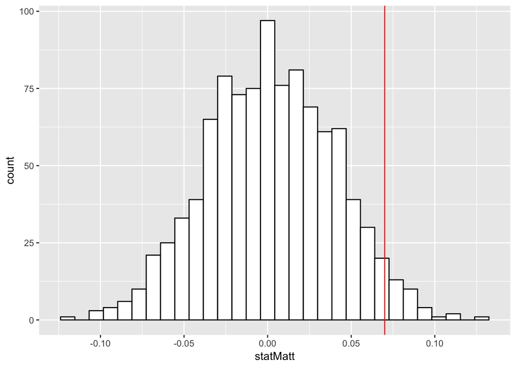

## Brandon

Sub Question: is ther a change of hydro energy consumption per person from 1989 to 2009

Null Hypothesis: There is no signifigant change in energy consumption

Alternative: There is signifigant change in energy consumption

```r
  hydro <- read_csv("hydro_power_generation_per_person.csv")  %>%
  gather(2:53, key="year", value="HydroperPerson", convert = TRUE)  %>% na.omit()

 # Hydro per person = Hydro consumption per person
hydro80 <- hydro %>% filter(between(year, 1980, 1989)) %>% select(year, HydroperPerson)
hydro09 <- hydro %>% filter(between(year, 2000, 2009)) %>% select(year, HydroperPerson)
```

```r
permTestBrandon <- function(x, y, n, func) {
  set.seed(1)
  output <- vector("double", length(n))
  master <- rbind(x, y)
  for (i in c(1:n)) {
    sample <- sample(nrow(master), min(nrow(x), nrow(y)))
    randomX <- master[sample,]
    randomY <- master[-sample,]

    meanX <- map_dbl(randomX, func)
    meanY <- map_dbl(randomY, func)

    output[[i]] <- meanX[[2]] - meanY[[2]]
  }
  return(output)
}
```

```r
stat <- permTestBrandon(hydro80, hydro09, 1000, mean)
realsX <- mean(hydro80$HydroperPerson)
realsY <- mean(hydro09$HydroperPerson)
percentile <- sum(stat < (realsX-realsY))/length(stat)*100
```

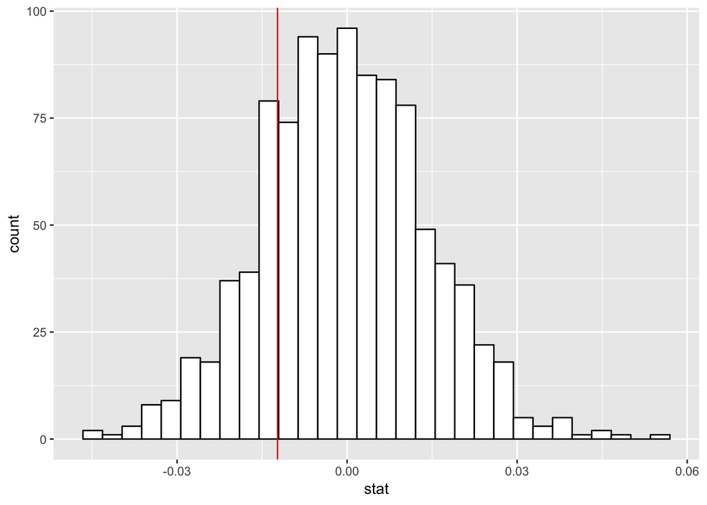

### Nick

Sub question: Has Europe’s consumption of oil experienced a significant decrease from 1985 to 2010

Null hypothesis: Consumption hasn’t changed

Altenate hypothesis: Consumption has changed

Test statistic: Average oil consumption per person in Europe

```r
library(gapminder)
europe_countries <- gapminder %>% filter(continent == "Europe")
europe_countries <- unique(europe_countries$country)

oil <- read_csv("oil_consumption_per_cap.csv")
oil <- filter(oil, country %in% europe_countries)
oil <- oil %>% gather(2:53, key = "year", value = "Oil/Person", na.rm = TRUE, convert = TRUE)

oil_1985 <- oil %>% filter(between(year, 1985, 1990)) %>% select(year, `Oil/Person`)
oil_2010 <- oil %>% filter(between(year, 2005, 2010)) %>% select(year, `Oil/Person`)
```

[figure not shown]